# Chapter 3 Homework

1678226 Chanmi Yoo (유찬미)

Regression Analysis  
20657-02  
Jae Keun Yoo  
Oct 14, 2019

### Q3.4

### (a)

The dot plot for the number of copiers serviced $X_i$ is:

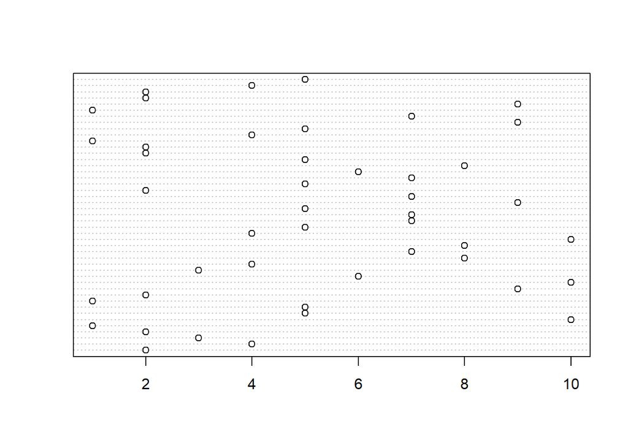

```r
data0304 <- read.table("../Data Sets/Chapter  3 Data Sets/CH03PR04.txt"); names(data0304) <- c("Y", "X", "X2", "X3")
lm.0304 <- lm(Y~X, data=data0304)

dotchart(data0304$X)
```

This plot shows that they are evenly distributed and there is no outlier.

### (b)

The time plot for the number of copiers serviced is:

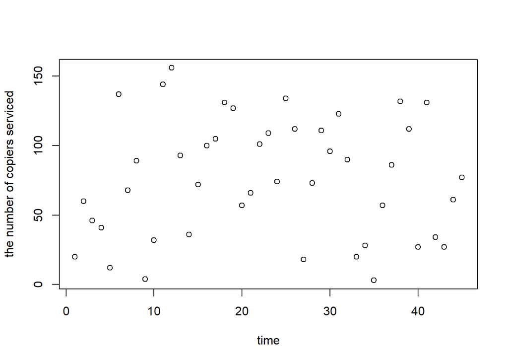

```r
plot(seq(nrow(data0304)), data0304$Y,
     xlab = "time", ylab = "the number of copiers serviced")
```

There is no special pattern in this time plot. The number of copiers serviced was not correlated over time.

### (c)

The stem-and-leaf plot of the residuals is:

```r
resd <- lm.0304$resid
stem(resd)
```

```
##
##   The decimal point is 1 digit(s) to the right of the |
##
##   -2 | 30
##   -1 |
##   -1 | 3110
##   -0 | 99997
##   -0 | 44333222111
##    0 | 001123334
##    0 | 5666779
##    1 | 112234
##    1 | 5
```

### (d)

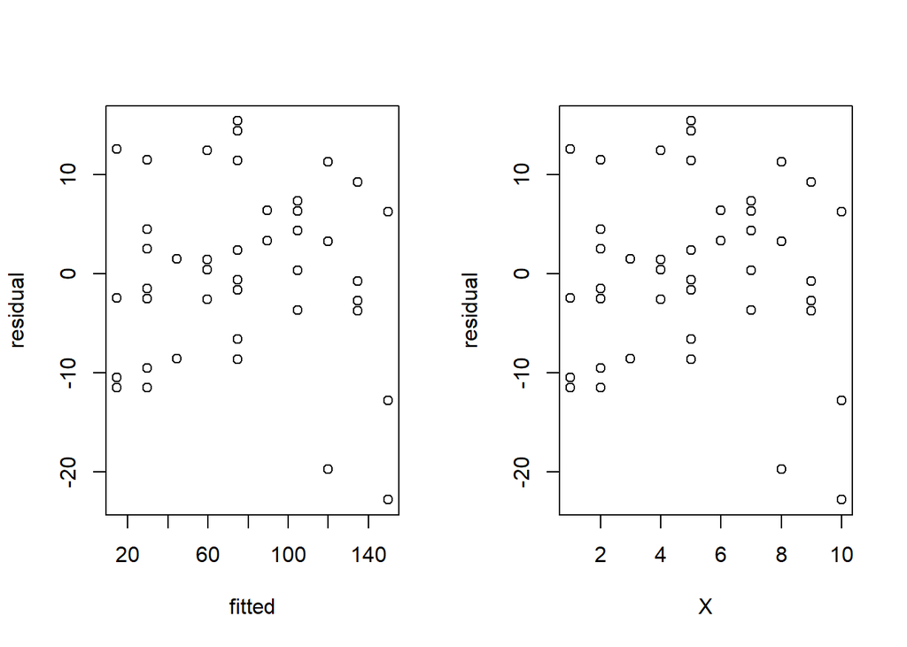

```r
fitted <- lm.0304$fitted

abs.resd <- abs(resd)

sqrt.mse <- summary(lm.0304)[[6]]; std.resd <- resd / sqrt.mse

par(mfrow=c(1,2))  #화면을 1*2로 분할
plot(fitted, resd,
     xlab="fitted", ylab="residual")
plot(data0304$X, resd,
     xlab="X", ylab="residual")
```

Yes, two plots provide the same information.  
Since the variance of residuals seems to be constant over different $X$ and $\hat Y$ levels, errors($\varepsilon_i$) have constant variance. The constant variance assumption of simple linear regression was not violated.

### (e)

```r
new_resd <- order(resd)
qq.r <- qqnorm(new_resd); qq.r
```

```
## $x
##  [1] -0.22468772 -0.40036338 -1.16394958  0.22468772  0.72791329
##  [6] -0.88199821 -2.28654795  0.58945580 -0.11163715 -0.52440051
## [11] -1.06056224  1.28155157 -0.05573169  0.96742157 -0.16789400
## [16]  0.80257189  1.59321882 -1.28155157  0.28221615  0.65710857
## [21]  0.11163715  0.05573169 -0.34069483 -1.83391464  1.83391464
## [26] -1.59321882  2.28654795 -0.80257189  0.46149369 -0.58945580
## [31]  0.00000000  1.42017907 -0.65710857  0.34069483  0.40036338
## [36]  0.16789400  1.06056224 -0.72791329 -0.28221615  0.88199821
## [41] -1.42017907 -0.46149369  1.16394958 -0.96742157  0.52440051
##
## $y
##  [1] 19 16  6 27 35  9  1 33 21 14  7 41 22 38 20 36 43  5 28 34 25 24 17
## [24]  2 44  3 45 10 31 13 23 42 12 29 30 26 39 11 18 37  4 15 40  8 32
```

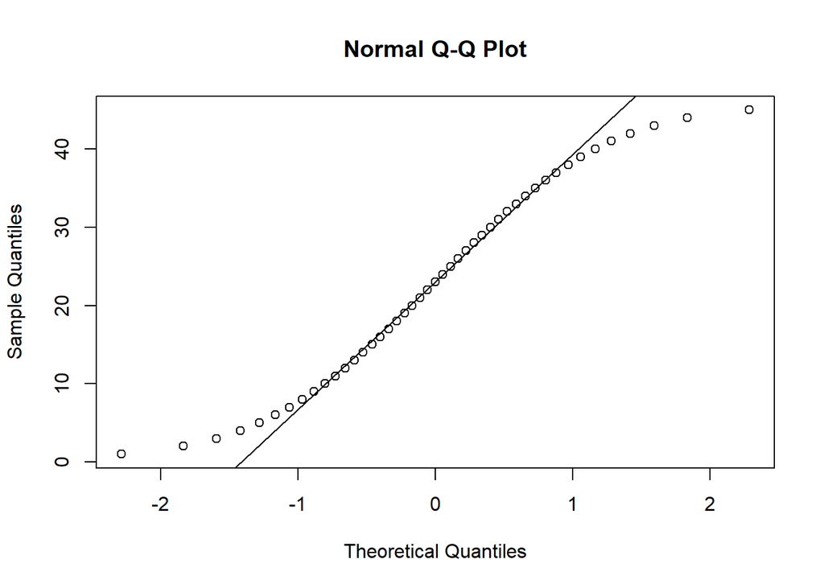

```r
qqline(new_resd)
```

```r
cor(qq.r$x, qq.r$y)
```

```
## [1] 0.9821998
```

### (f)

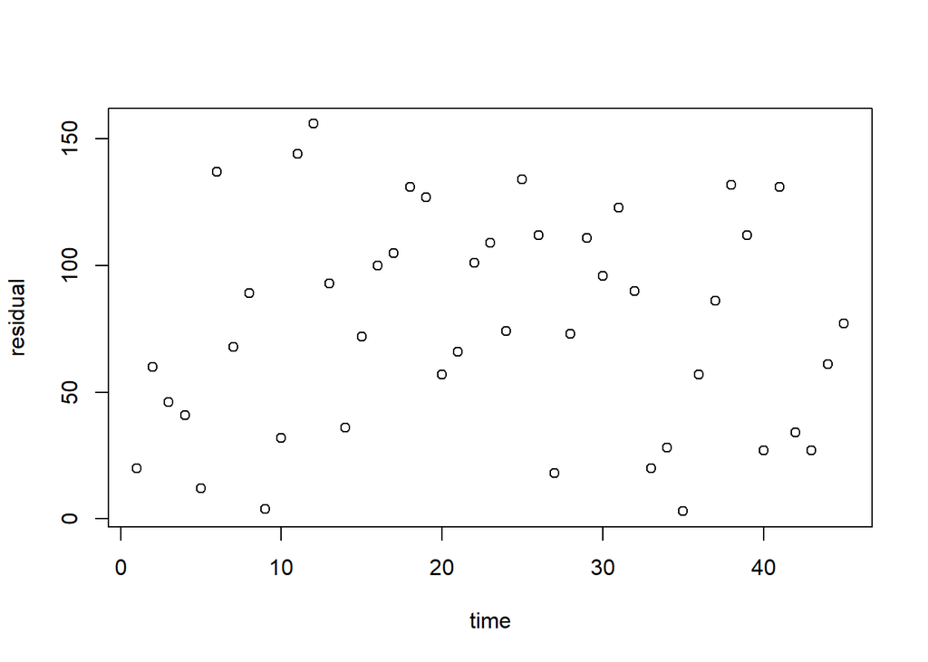

```r
plot(seq(nrow(data0304)), data0304$Y,
     xlab="time", ylab="residual")
```

### (g)

To check whether if the error variance varies with the level of X, the alternatives would be:

$$\begin{cases}H_0 \;:\; \gamma_{1} = 0 \\
H_a \;:\; \gamma_{1} \neq 0
\end{cases}$$
at $\alpha = .05$

```r
ano <- anova(lm.0304)
ssr <- ano$`Sum Sq`[[1]]; ssr
```

```
## [1] 76960.42
```

```r
sse <- ano$`Sum Sq`[[2]]; sse
```

```
## [1] 3416.377
```

Hence the test statistic is:

The decision rule is:

$$\begin{cases}\text{If } |X^2_{BP}| \leq \chi^2( .95 \; ; \, 1) \text{, conclude } H_0 \\
\text{If } |X^2_{BP}| > \chi^2( .95 \; ; \, 1) \text{, reject } H_0 \end{cases}$$

$\chi^2( .95 \; ; \, 1)$ is:

```r
round(qchisq(.95, 1), 4)
```

```
## [1] 3.8415
```

### (h)

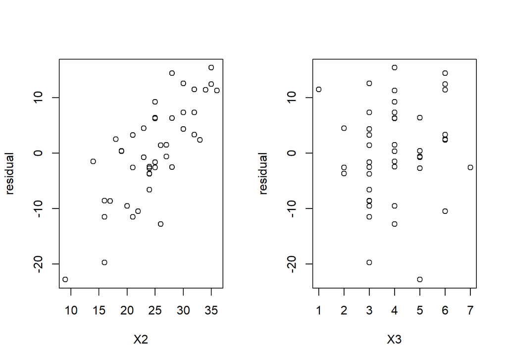

```r
par(mfrow=c(1,2))
plot(data0304$X2, resd,
     xlab="X2", ylab="residual")
plot(data0304$X3, resd,
     xlab="X3", ylab="residual")
```

The residual versus $X_2$ plot showed a positive linear trend. It means that the regression model might be improved by including $X_2$.  
The residual versus $X_3$ plot did not show any special pattern. So, adding $X_3$ into the model may not bring any improvement in terms of model fitting.

### Q3.6

### (a)

```r
data0306 <- read.table("../Data Sets/Chapter  1 Data Sets/CH01PR22.txt"); names(data0306) <- c("Y", "X")
lm.0306 <- lm(Y~X, data=data0306)
resd <- lm.0306$residuals; resd
```

```
##      1      2      3      4      5      6      7      8      9     10
## -2.150  3.850 -5.150 -1.150  0.575  2.575 -2.425  5.575  3.300  0.300
##     11     12     13     14     15     16
##  1.300 -3.700  0.025 -1.975  3.025 -3.975
```

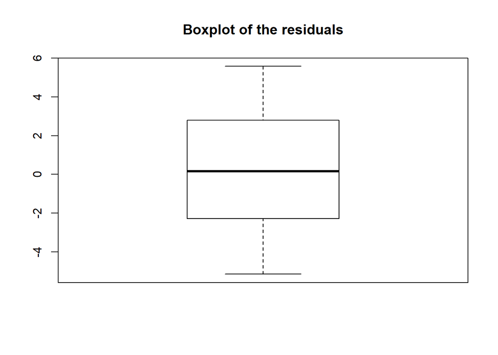

```r
boxplot(resd, main = "Boxplot of the residuals")
```

The distribution of residuals is symmetric with the mean of 0.

### (b)

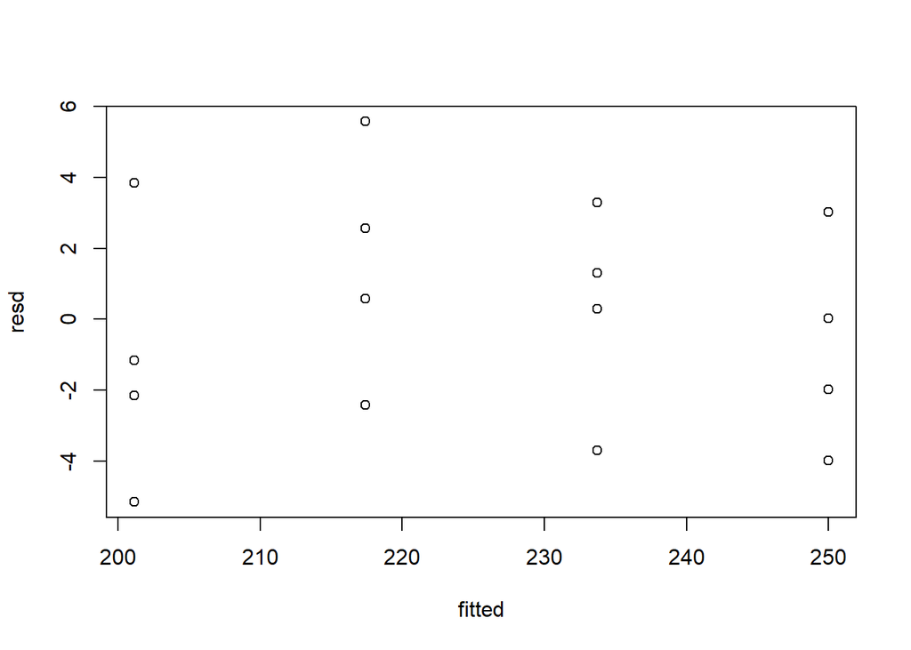

```r
fitted <- lm.0306$fitted.values
plot(fitted, resd)
```

There is no special pattern in the residual versus fitted plot. The range of fitted values is (200, 250) and residuals are evenly distributed. Thus, the error variance is constant.

### (c)

```r
qq.r <- qqnorm(resd); qq.r
```

```
## $x
##  [1] -0.57913216  1.31801090 -1.86273187 -0.23720211  0.23720211
##  [6]  0.57913216 -0.77642176  1.86273187  1.00999017  0.07841241
## [11]  0.40225007 -1.00999017 -0.07841241 -0.40225007  0.77642176
## [16] -1.31801090
##
## $y
##      1      2      3      4      5      6      7      8      9     10
## -2.150  3.850 -5.150 -1.150  0.575  2.575 -2.425  5.575  3.300  0.300
##     11     12     13     14     15     16
##  1.300 -3.700  0.025 -1.975  3.025 -3.975
```

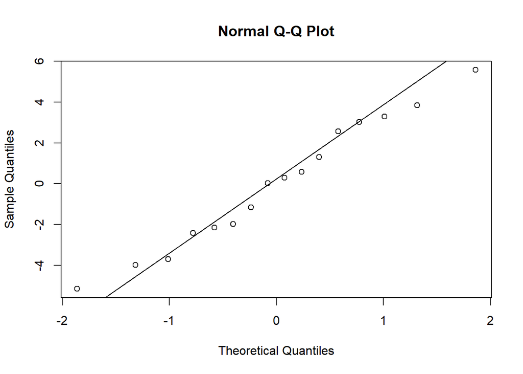

```r
qqline(resd)
```

```r
cor(qq.r$x, qq.r$y)
```

```
## [1] 0.9905063
```

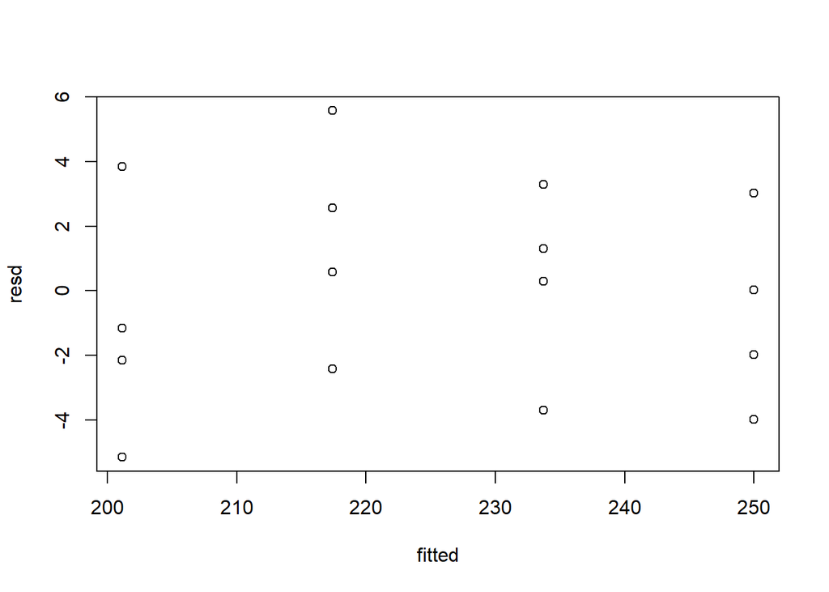

```r
plot(fitted, resd)
```

### (d)

```r
qt(0.25,15); qt(0.5,15); qt(0.75,15); qt(1,15)
```

```
## [1] -0.6911969
```

```
## [1] 0
```

```
## [1] 0.6911969
```

```
## [1] Inf
```

### (e)

To check whether if the error variance varies with the level of X, the alternatives would be:

$$\begin{cases}H_0 \;:\; d_{i1} - d_{i2} = 0 \text{ (The variance of residuals from two groups are equal)} \\
H_a \;:\; d_{i1} - d_{i2} \neq 0 \text{ (The variance of residuals from two groups are not equal)}
\end{cases}$$
at $\alpha = .05$

```r
nrow(data0306)  # Since the number of observed vaules is 16, divide the groups in to size of 8 each.
```

```
## [1] 16
```

```r
resd1 <- resd[1:8]
resd2 <- resd[9:16]
d1 <- sum(abs(resd1-median(resd1)))
d2 <- sum(abs(resd2-median(resd2)))
d1 - d2
```

```
## [1] 5.9
```

```r
s <- sqrt((sum((resd1-median(resd1))^2) + sum((resd2-median(resd2))^2) ) / nrow(data0306) - 2); s
```

```
## [1] 2.702169
```

Hence the test statistic is:

The decision rule is:

$$\begin{cases}\text{If } |t^*_{BP}| \leq t( .95 \; ; \, 14) \text{, conclude } H_0 \\
\text{If } |t^*_{BP}| > t( .95 \; ; \, 14) \text{, reject } H_0 \end{cases}$$

```r
round(qt(.95, 14), 4)
```

```
## [1] 1.7613
```